# HW2

Adaeze Obinelo

## Setup

```r
library(dplyr)
library(tidyverse)
library(data.table)
```

```r
library(ggplot2)

ind <- read_csv('chs_individual.csv')
reg <- read.csv('chs_regional.csv')
chs <- merge(ind, reg, by= 'townname')
```

## 1

```r
duplicated(chs)
```

[output not shown]

[output cut: 85 more lines]

It appears that there are no duplicate entries based on this

## 2

```r
chs$obesity_level <- as.factor(ifelse(chs$bmi<14, 'underweight',
                                      ifelse(chs$bmi<22, 'normal',
                                             ifelse(chs$bmi<24, 'overweight',
                                                    ifelse(chs$bmi<44, 'obese')))))

chs %>%
  summarise(
  first = min(bmi),
  last = max(bmi)
  )
```

```
##   first last
## 1    NA   NA
```

```r
chs %>%
  group_by(obesity_level) %>%
  count(bmi)
```

```
## # A tibble: 702 × 3
## # Groups:   obesity_level [5]
##    obesity_level   bmi     n
##    <fct>         <dbl> <int>
##  1 normal         14.0     1
##  2 normal         14.1     1
##  3 normal         14.1     1
##  4 normal         14.1     1
##  5 normal         14.1     4
##  6 normal         14.1     2
##  7 normal         14.2     3
##  8 normal         14.2     1
##  9 normal         14.2     1
## 10 normal         14.3     1
## # ℹ 692 more rows
```

## 3

```r
chs$exposure <- ifelse((chs$smoke == 1) & (chs$gasstove==1), 'both',
                       ifelse((chs$smoke == 0) & (chs$gasstove==1), 'gas',
                              ifelse((chs$smoke == 1) & (chs$gasstove==0), 'smoke',
                                     ifelse((chs$smoke == 0) & (chs$gasstove==0), 'none', NA))))

head(chs)
```

```
##   townname sid male race hispanic    agepft height weight      bmi asthma
## 1   Alpine 841    1    W        1 10.548939    150     78 15.75758      0
## 2   Alpine 835    0    W        0 10.099932    143     69 15.33749      0
## 3   Alpine 838    0    O        1  9.486653    133     62 15.93183      0
## 4   Alpine 840    0    W        0  9.965777    146     78 16.63283      0
## 5   Alpine 865    0    W        0 10.039699    162    140 24.24797      1
## 6   Alpine 867    0    W        1  9.957563    141     94 21.49151      0
##   active_asthma father_asthma mother_asthma wheeze hayfever allergy educ_parent
## 1             0             0             0      0        0       0           5
## 2             0             0             0      0        0       1           3
## 3             0             0             0      0        0       0           4
## 4             0             0             0      0        0       0          NA
## 5             1             0             0      1        0       1           3
## 6             0            NA             0      0        0       0           5
##   smoke pets gasstove      fev      fvc     mmef pm25_mass pm25_so4 pm25_no3
```

[output cut: 27 more lines]

## 4

```r
chs %>%
  group_by(townname) %>%
  summarise(
    FEV1 = mean(fev, na.rm=TRUE),
    Std = sd(fev)
  )
```

```
## # A tibble: 12 × 3
##    townname       FEV1   Std
##    <chr>         <dbl> <dbl>
##  1 Alpine        2089.    NA
##  2 Atascadero    2079.    NA
##  3 Lake Elsinore 2040.    NA
##  4 Lake Gregory  2092.    NA
##  5 Lancaster     2003.    NA
##  6 Lompoc        2038.    NA
##  7 Long Beach    1984.    NA
##  8 Mira Loma     1985.    NA
##  9 Riverside     1986.    NA
## 10 San Dimas     2028.    NA
## 11 Santa Maria   2023.    NA
## 12 Upland        2027.    NA
```

```r
chs %>%
  group_by(male) %>%
  summarise(
    FEV1 = mean(fev, na.rm=TRUE))
```

```
## # A tibble: 2 × 2
##    male  FEV1
##   <dbl> <dbl>
## 1     0 1959.
## 2     1 2104.
```

```r
chs %>%
  group_by(obesity_level) %>%
  summarise(
    FEV1 = mean(fev, na.rm=TRUE))
```

```
## # A tibble: 5 × 2
##   obesity_level  FEV1
##   <fct>         <dbl>
## 1 normal        1998.
## 2 obese         2269.
## 3 overweight    2224.
## 4 underweight   1687.
## 5 <NA>           NaN
```

```r
chs %>%
  group_by(exposure) %>%
  summarise(
    FEV1 = mean(fev, na.rm=TRUE))
```

```
## # A tibble: 5 × 2
##   exposure  FEV1
##   <chr>    <dbl>
## 1 both     2020.
## 2 gas      2026.
## 3 none     2060.
## 4 smoke    2064.
## 5 <NA>     2000.
```

## 1. Check packaging

```r
nrow(chs)
```

```
## [1] 1200
```

```r
ncol(chs)
```

```
## [1] 51
```

## 2. Check structure

```r
str(chs)
```

```
## 'data.frame':    1200 obs. of  51 variables:
##  $ townname     : chr  "Alpine" "Alpine" "Alpine" "Alpine" ...
##  $ sid          : num  841 835 838 840 865 867 842 839 844 847 ...
##  $ male         : num  1 0 0 0 0 0 1 0 1 1 ...
##  $ race         : chr  "W" "W" "O" "W" ...
##  $ hispanic     : num  1 0 1 0 0 1 1 1 1 0 ...
##  $ agepft       : num  10.55 10.1 9.49 9.97 10.04 ...
##  $ height       : num  150 143 133 146 162 141 139 142 143 137 ...
##  $ weight       : num  78 69 62 78 140 94 65 86 65 69 ...
##  $ bmi          : num  15.8 15.3 15.9 16.6 24.2 ...
##  $ asthma       : num  0 0 0 0 1 0 0 0 NA 0 ...
##  $ active_asthma: num  0 0 0 0 1 0 0 0 0 0 ...
##  $ father_asthma: num  0 0 0 0 0 NA 0 0 NA 0 ...
##  $ mother_asthma: num  0 0 0 0 0 0 0 1 NA 0 ...
##  $ wheeze       : num  0 0 0 0 1 0 1 1 NA 0 ...
```

[output cut: 37 more lines]

## Look at top and bottom

```r
head(chs)
```

```
##   townname sid male race hispanic    agepft height weight      bmi asthma
## 1   Alpine 841    1    W        1 10.548939    150     78 15.75758      0
## 2   Alpine 835    0    W        0 10.099932    143     69 15.33749      0
## 3   Alpine 838    0    O        1  9.486653    133     62 15.93183      0
## 4   Alpine 840    0    W        0  9.965777    146     78 16.63283      0
## 5   Alpine 865    0    W        0 10.039699    162    140 24.24797      1
## 6   Alpine 867    0    W        1  9.957563    141     94 21.49151      0
##   active_asthma father_asthma mother_asthma wheeze hayfever allergy educ_parent
## 1             0             0             0      0        0       0           5
## 2             0             0             0      0        0       1           3
## 3             0             0             0      0        0       0           4
## 4             0             0             0      0        0       0          NA
## 5             1             0             0      1        0       1           3
## 6             0            NA             0      0        0       0           5
##   smoke pets gasstove      fev      fvc     mmef pm25_mass pm25_so4 pm25_no3
```

[output cut: 27 more lines]

```r
tail(chs)
```

```
##      townname  sid male race hispanic    agepft height weight      bmi asthma
## 1195   Upland 1866    0    O        1  9.806982    139     60 14.11559      0
## 1196   Upland 1867    0    M        1  9.618070    140     71 16.46568      0
## 1197   Upland 2033    0    M        0 10.121834    130     67 18.02044      0
## 1198   Upland 2031    1    W        0  9.798768    135     83 20.70084      0
## 1199   Upland 2032    1    W        0  9.549624    137     59 14.28855      0
## 1200   Upland 2053    0    W        0        NA     NA     NA       NA      0
##      active_asthma father_asthma mother_asthma wheeze hayfever allergy
## 1195             0            NA             0      0       NA      NA
## 1196             0             1             0      0        0       0
## 1197             1             0             0      1        1       0
## 1198             0             0             0      1        0       1
## 1199             0             0             1      1        1       1
## 1200             0             0             0      0        0       0
##      educ_parent smoke pets gasstove      fev      fvc     mmef pm25_mass
```

[output cut: 27 more lines]

## Check for NAs

3. I see some above, likely there are more, so I will check the variables of interest

```r
chs %>%
  filter(is.na(agepft))%>%
  select(sid, height, weight, bmi)
```

```
##     sid height weight bmi
## 1   936     NA     NA  NA
## 2   870     NA     NA  NA
## 3  1155     NA     NA  NA
## 4  1154     NA     NA  NA
## 5   431     NA     NA  NA
## 6   496     NA     NA  NA
## 7   500     NA     NA  NA
## 8   509     NA     NA  NA
## 9   456     NA     NA  NA
## 10 1067     NA     NA  NA
## 11 1024     NA     NA  NA
## 12 1031     NA     NA  NA
## 13 1034     NA     NA  NA
## 14 1121     NA     NA  NA
```

[output cut: 75 more lines]

```r
chs %>%
  filter(is.na(weight))%>%
  select(sid, height, weight, bmi)
```

```
##     sid height weight bmi
## 1   936     NA     NA  NA
## 2   870     NA     NA  NA
## 3  1155     NA     NA  NA
## 4  1154     NA     NA  NA
## 5   431     NA     NA  NA
## 6   496     NA     NA  NA
## 7   500     NA     NA  NA
## 8   509     NA     NA  NA
## 9   456     NA     NA  NA
## 10 1067     NA     NA  NA
## 11 1024     NA     NA  NA
## 12 1031     NA     NA  NA
## 13 1034     NA     NA  NA
## 14 1121     NA     NA  NA
```

[output cut: 75 more lines]

```r
chs %>%
  filter(is.na(bmi))%>%
  select(sid, height, weight, bmi)
```

```
##     sid height weight bmi
## 1   936     NA     NA  NA
## 2   870     NA     NA  NA
## 3  1155     NA     NA  NA
## 4  1154     NA     NA  NA
## 5   431     NA     NA  NA
## 6   496     NA     NA  NA
## 7   500     NA     NA  NA
## 8   509     NA     NA  NA
## 9   456     NA     NA  NA
## 10 1067     NA     NA  NA
## 11 1024     NA     NA  NA
## 12 1031     NA     NA  NA
## 13 1034     NA     NA  NA
## 14 1121     NA     NA  NA
```

[output cut: 75 more lines]

```r
chs %>%
  filter(is.na(height))%>%
  select(sid, height, weight, bmi)
```

```
##     sid height weight bmi
## 1   936     NA     NA  NA
## 2   870     NA     NA  NA
## 3  1155     NA     NA  NA
## 4  1154     NA     NA  NA
## 5   431     NA     NA  NA
## 6   496     NA     NA  NA
## 7   500     NA     NA  NA
## 8   509     NA     NA  NA
## 9   456     NA     NA  NA
## 10 1067     NA     NA  NA
## 11 1024     NA     NA  NA
## 12 1031     NA     NA  NA
## 13 1034     NA     NA  NA
## 14 1121     NA     NA  NA
```

[output cut: 75 more lines]

```r
chs %>%
  filter(is.na(asthma))%>%
  select(sid, height, weight, bmi, asthma, fev, pm25_mass, exposure)%>%
  arrange(desc(sid))
```

```
##     sid height weight      bmi asthma      fev pm25_mass exposure
## 1  1999    134     65 16.45436     NA 1996.000      5.96     <NA>
## 2  1970    135     65 16.21150     NA 1925.743      5.96     <NA>
## 3  1955    131     69 18.27611     NA 1753.618      5.96      gas
## 4  1751    132     76 19.82636     NA 1749.099     22.46     none
## 5  1658     NA     NA       NA     NA       NA      7.19     <NA>
## 6  1556    140     72 16.69759     NA 2284.768      7.19     none
## 7  1555     NA     NA       NA     NA       NA      7.19    smoke
## 8  1536    135     60 14.96446     NA 1715.842     19.12     <NA>
## 9  1451    142     81 18.25936     NA 2268.000     19.12     both
## 10 1443    141     90 20.57698     NA 2329.254     19.12     both
## 11 1389     NA     NA       NA     NA       NA     19.12      gas
## 12 1265     NA     NA       NA     NA       NA      7.66     <NA>
## 13 1175    144    143 31.34645     NA 2237.705     12.35     both
## 14 1089    129     53 14.47684     NA 1812.081     12.35     <NA>
```

[output cut: 17 more lines]

```r
chs %>%
  filter(is.na(fev))%>%
  select(sid, height, weight, bmi, fev, pm25_mass, exposure) %>%
  arrange(desc(sid))
```

```
##     sid height weight      bmi fev pm25_mass exposure
## 1  2053     NA     NA       NA  NA     22.46     none
## 2  2036     NA     NA       NA  NA      5.96      gas
## 3  2025     NA     NA       NA  NA      5.96      gas
## 4  1983     NA     NA       NA  NA      5.96      gas
## 5  1946     NA     NA       NA  NA      5.96     both
## 6  1915     NA     NA       NA  NA      5.96     both
## 7  1908     NA     NA       NA  NA      5.96     none
## 8  1903     NA     NA       NA  NA      5.96      gas
## 9  1889     NA     NA       NA  NA      5.96     both
## 10 1868     NA     NA       NA  NA      5.96      gas
## 11 1863     NA     NA       NA  NA     22.46      gas
## 12 1862     NA     NA       NA  NA     22.46     none
## 13 1860    136     62 15.23671  NA     22.46     none
## 14 1854     NA     NA       NA  NA     22.46      gas
```

[output cut: 81 more lines]

```r
chs %>%
  filter(is.na(pm25_mass))%>%
  select(sid, height, weight, bmi, fev, pm25_mass, exposure)%>%
  arrange(desc(sid))
```

```
## [1] sid       height    weight    bmi       fev       pm25_mass exposure
## <0 rows> (or 0-length row.names)
```

```r
chs %>%
  filter(is.na(exposure)) %>%
  select(sid, height, weight, bmi, fev, pm25_mass, exposure)%>%
  arrange(desc(sid))
```

```
##     sid height weight      bmi       fev pm25_mass exposure
## 1  1999    134     65 16.45436 1996.0000      5.96     <NA>
## 2  1987    130     78 20.97902 1776.7677      5.96     <NA>
## 3  1970    135     65 16.21150 1925.7426      5.96     <NA>
## 4  1879    144     78 17.09806 2665.9975      5.96     <NA>
## 5  1850    143     86 19.11629 2428.6722     22.46     <NA>
## 6  1660    138    103 24.58422 1814.0671      7.19     <NA>
## 7  1658     NA     NA       NA        NA      7.19     <NA>
## 8  1645    136     73 17.94000 1912.5000      7.19     <NA>
## 9  1644    134     81 20.50467 1737.3737      7.19     <NA>
## 10 1631    144    117 25.64710 2302.9530      7.19     <NA>
## 11 1618    144    115 25.20868 2234.2105      7.19     <NA>
## 12 1587    135     95 23.69373 2083.9465      7.19     <NA>
## 13 1536    135     60 14.96446 1715.8416     19.12     <NA>
## 14 1531    147     79 16.61766 1334.3434     19.12     <NA>
```

[output cut: 46 more lines]

The NAs in the demographic data seem to be grouped, while the not all observations missing one outcome measure are missing all the others.

Simplified view of NA’s found above (there are a lot in other variables we don’t care about too)

```r
chs %>%
  select_if(function(x) any(is.na(x)))%>%
  summarise_each(funs(sum(is.na(.))))
```

```
##   agepft height weight bmi asthma father_asthma mother_asthma wheeze hayfever
## 1     89     89     89  89     31           106            56     71      118
##   allergy educ_parent smoke gasstove fev fvc mmef no_24hr pm2_5_fr
## 1      63          64    40       33  95  97  106     100      300
##   obesity_level exposure
## 1            89       60
```

I’m going to omit any observation with an NA, even the ones with just NAs in variables we don’t care about

```r
chs <- na.omit(chs)

nrow(chs)
```

```
## [1] 519
```

```r
ncol(chs)
```

```
## [1] 51
```

Dataset is now much smaller

## 4. Validate w external data source:

```r
library(leaflet)

PM.pal<- colorNumeric(c('darkblue','orange','red'), domain=chs$pm25_mass)

leaflet(chs) %>%
  addProviderTiles('CartoDB.Positron') %>%
  addCircles(lat = ~lat, lng = ~lon,
             label = ~paste0(round(pm25_mass, 2)), color = ~ PM.pal(pm25_mass),
             opacity = 1, fillOpacity = 1, radius = 500
             ) %>%
  addLegend('bottomleft', pal=PM.pal, values=chs$pm25_mass,
            title= "PM_25 Mass emissions", opacity = 1)
```

[interactive chart not shown]

I’m going to choose to validate our data based on PM2.5 because we have state wide-pm2.5 data from the dataset we used in HW1 (hope this is ok)

```r
one <- read_csv('2002data.csv')
two <- read.csv('2022data.csv')

names(two)[names(two) == "Daily.Mean.PM2.5.Concentration"] <- "Daily Mean PM2.5 Concentration"

names(two)[names(two) == "Site.Name"] <- "Site Name"

names(two)[names(two) == "Site.ID"] <- "Site ID"

one <- na.omit(one)
two <- na.omit(two)

hw1 <- rbind(one, two)

chs %>%
  count(townname)
```

```
##        townname  n
## 1        Alpine 62
## 2 Lake Elsinore 61
## 3    Long Beach 62
## 4     Mira Loma 64
## 5     Riverside 63
## 6     San Dimas 74
## 7   Santa Maria 60
## 8        Upland 73
```

```r
names(hw1)[names(hw1)== "Site Name"] <- "townname"
names(hw1)[names(hw1)== "SITE_LATITUDE"] <- "LAT"
names(hw1)[names(hw1)== "SITE_LONGITUDE"] <- "LON"
names(hw1)[names(hw1)== "Daily Mean PM2.5 Concentration"] <- "PM"
```

Above, I loaded our hw1 dataset, and looked at the townnames we have represented in our chs dataset –> I want to only select the observations from our hw1 dataset that are matched for location (changed the variable name from site name to make this easier).

```r
check <- hw1[grep("Alpine|Lake Elsinore|Long Beach|Mira Loma|Riverside|San Dimas|Santa Maria|Upland", hw1$townname), ]
```

Load a map of PM2.5 values for this dataset;

```r
library(leaflet)

hw.pal<- colorNumeric(c('darkblue','orange','red'), domain=check$PM)

leaflet(check) %>%
  addProviderTiles('CartoDB.Positron') %>%
  addCircles(lat = ~LAT, lng = ~LON,
             label = ~paste0(round(PM,2)), color = ~ hw.pal(PM),
             opacity = 1, fillOpacity = 1, radius = 500
             ) %>%
  addLegend('bottomleft', pal=hw.pal, values=check$PM,
            title= "PM_25 Mass emissions", opacity = 1)
```

[interactive chart not shown]

The scale is a bit different here, but the values seem comparable to what we have for our chs data if you look at the actual #s

Map the max of hw1 data to get better confirmation:

```r
meanscheck <- check %>%
  group_by(townname) %>%
  mutate(
    mean_pm = mean(PM))

meanscheck <- meanscheck %>%
  arrange(desc(mean_pm))

maxcheck <- first(meanscheck)
mincheck <- last(meanscheck)



leaflet() %>%
  addProviderTiles('CartoDB.Positron') %>%
  addCircles(
    data = maxcheck,
    lat = ~LAT, lng = ~LON, popup = "Max PM",
    opacity=1, fillOpacity=1, radius = 50, color = "red"
  )
```

[interactive chart not shown]

```r
maxcheck %>%
  select(townname)
```

```
## # A tibble: 1 × 1
## # Groups:   townname [1]
##   townname
##   <chr>
## 1 Riverside (Magnolia)
```

Max of chs data:

```r
means <- chs %>%
  group_by(townname) %>%
  mutate(
    mean_pm = mean(pm25_mass))

means <- means %>%
  arrange(desc(mean_pm))

max <- first(means)
min <- last(means)

leaflet() %>%
  addProviderTiles('CartoDB.Positron') %>%
  addCircles(
    data = max,
    lat = ~lat, lng = ~lon, popup = "Max PM",
    opacity=1, fillOpacity=1, radius = 50, color = "red"
  )
```

[interactive chart not shown]

```r
max %>%
  select(townname)
```

```
## # A tibble: 1 × 1
## # Groups:   townname [1]
##   townname
##   <chr>
## 1 Mira Loma
```

```r
leaflet() %>%
  addProviderTiles('CartoDB.Positron') %>%
  addCircles(
    data = maxcheck,
    lat = ~LAT, lng = ~LON, popup = "HW1 Max PM",
    opacity=1, fillOpacity=1, radius = 50, color = "red"
  ) %>%
  addCircles(
    data = max,
    lat = ~lat, lng = ~lon, popup = "CHS Max PM",
    opacity=1, fillOpacity=1, radius = 50, color = "red"
  )
```

[interactive chart not shown]

Max PM2.5 observations for both datasets are in different locations, but are in the same county (mira loma is in riverside) and very close to one another. Given this, and how closely our PM2.5 data from the chs dataset and the matched(ish) data from the state-wide recordings mirror one another, it appears that our chs data is valid enough.

## 5. Easy solution(s):

$a$ FEV vs BMI

```r
cor(chs$fev, chs$bmi, use="complete")
```

```
## [1] 0.3360608
```

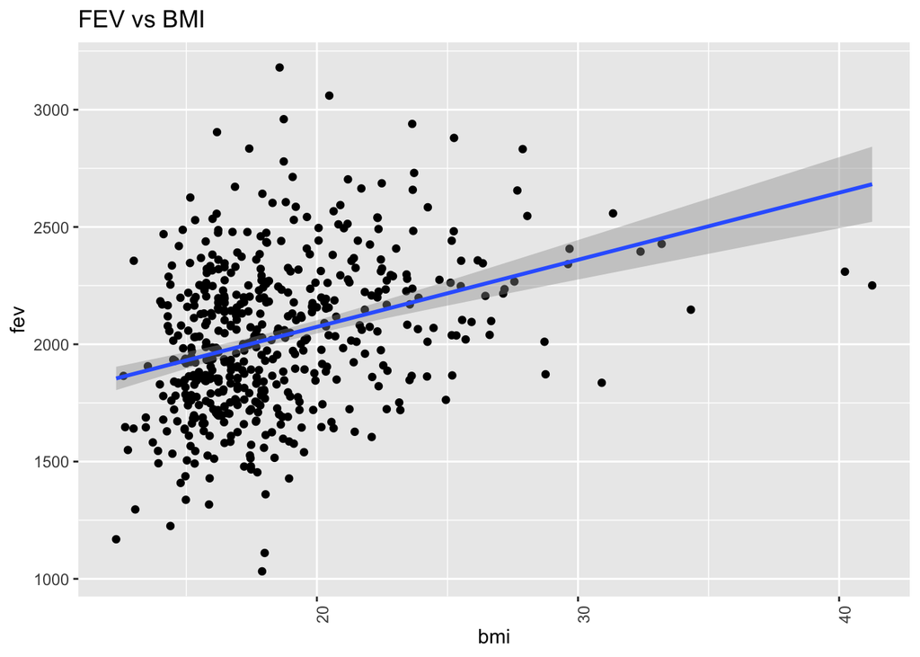

```r
chs %>%
  ggplot() +
  geom_point(mapping = aes(x = bmi, y = fev)) +
  geom_smooth(mapping = aes(x = bmi, y = fev), method = "lm") +
  theme(axis.text.x = element_text(angle = 90)) +
  labs(title = "FEV vs BMI")
```

Moderate positive correlation between BMI and FEV

$b$ Exposure vs FEV

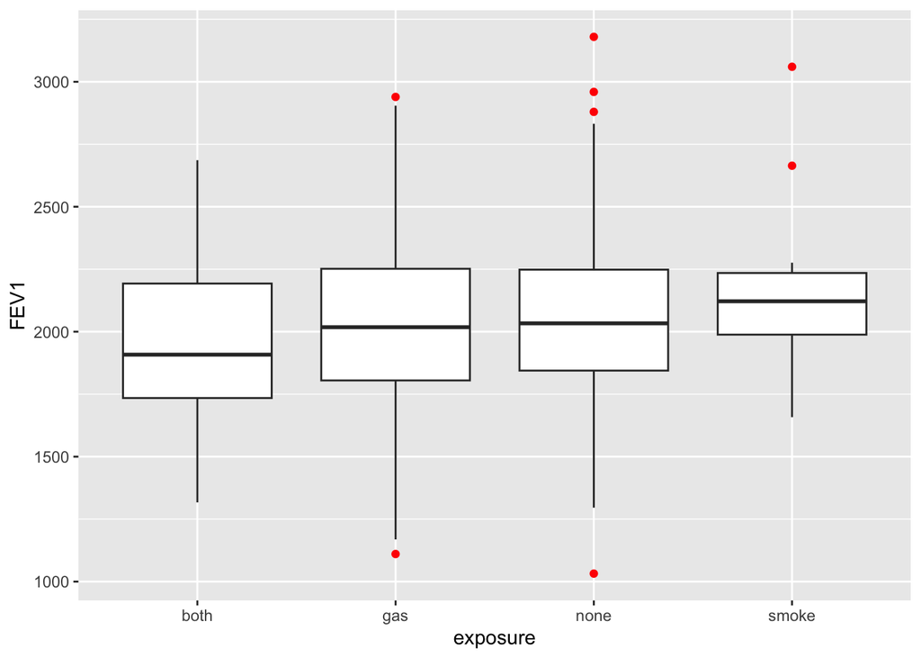

```r
library(broom)
library(ggpubr)

chs$exposurecat <- ifelse((chs$smoke == 1) & (chs$gasstove==1), 3,
                       ifelse((chs$smoke == 0) & (chs$gasstove==1), 2,
                              ifelse((chs$smoke == 1) & (chs$gasstove==0), 1,
                                     ifelse((chs$smoke == 0) & (chs$gasstove==0), 0, NA))))



ggplot(chs, aes(x=exposure, y=fev)) +
  geom_boxplot(outlier.colour='red') +
  coord_cartesian() +
  xlab(label = "exposure") +
  ylab(label = "FEV1")
```

Varying association withe exposure; Looking at the dispersion of our data it looks like the median smoke exposure has the highest mean FEV1 compared to the other groups, which is also not congruent with clinical reality. The presence of both exposures seems to be associated with the lowest median fev1, which is consistent with clinical reality. The “no exposure” group has the lowest outlier and a greater spread of data, while the smoke exposure group has only high outliers, which might be leading to the medians we observe.

$c$ FEV vs PM2.5:

```r
cor(chs$fev, chs$pm25_mass, use="complete")
```

```
## [1] -0.04507301
```

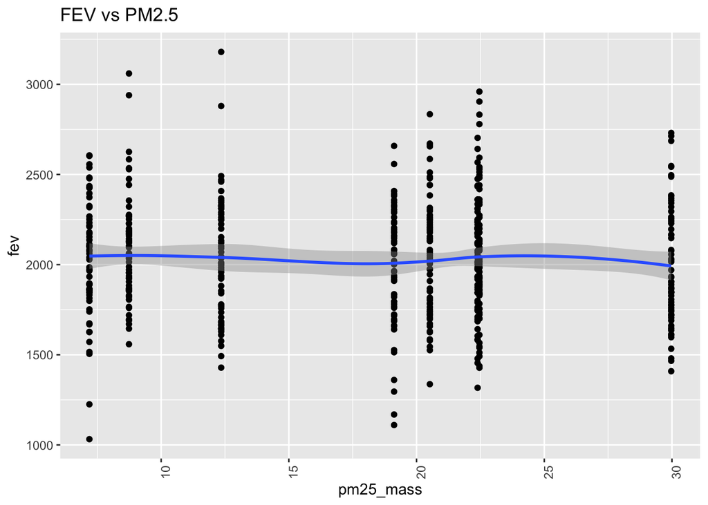

```r
chs %>%
  ggplot() +
  geom_point(mapping = aes(x = pm25_mass, y = fev)) +
  geom_smooth(mapping = aes(x = pm25_mass, y = fev)) +
  theme(axis.text.x = element_text(angle = 90)) +
  labs(title = "FEV vs PM2.5")
```

## 6. Challenge solutions:

$a$

```r
lmfevbmi = lm(fev~bmi, data = chs)
summary(lmfevbmi)
```

```
##
## Call:
## lm(formula = fev ~ bmi, data = chs)
##
## Residuals:
##     Min      1Q  Median      3Q     Max
## -982.20 -213.63  -10.57  191.99 1146.41
##
## Coefficients:
##             Estimate Std. Error t value Pr(>|t|)
## (Intercept) 1502.339     66.384  22.631  < 2e-16 ***
## bmi           28.594      3.524   8.113 3.62e-15 ***
## ---
## Signif. codes:  0 '***' 0.001 '**' 0.01 '*' 0.05 '.' 0.1 ' ' 1
##
## Residual standard error: 303.4 on 517 degrees of freedom
## Multiple R-squared:  0.1129, Adjusted R-squared:  0.1112
## F-statistic: 65.82 on 1 and 517 DF,  p-value: 3.618e-15
```

Positive correlation between BMI and FEV; each level increase in BMI is associated with a 28.59x increase in FEV (within our datarange).

$b$

```r
group_by(chs, exposurecat) %>%
  summarise(
    count = n(),
    mean = mean(pm25_mass, na.rm = TRUE),
    sd = sd(pm25_mass, na.rm = TRUE),
    median = median(pm25_mass, na.rm = TRUE),
    IQR = IQR(pm25_mass, na.rm = TRUE)
  )
```

```
## # A tibble: 4 × 6
##   exposurecat count  mean    sd median   IQR
##         <dbl> <int> <dbl> <dbl>  <dbl> <dbl>
## 1           0   113  15.1  6.62  12.4   13.6
## 2           1    13  13.5  6.26   8.74  11.8
## 3           2   331  19.0  6.92  20.5   10.1
## 4           3    62  19.6  7.88  19.1   15.7
```

Looking at the statistics, the variation between observation count is probably what gave us our weird results (the means make even less sense than the medians)

Confirm SS diff between groups w KW test (non-parametric), then do multiple level comparisons to find which group(/s) is SS from the rest (if there is a diff):

```r
library(ggpubr)
kruskal.test(fev ~ exposurecat, data = chs)
```

```
##
##  Kruskal-Wallis rank sum test
##
## data:  fev by exposurecat
## Kruskal-Wallis chi-squared = 3.3363, df = 3, p-value = 0.3426
```

No SS difference between fev based on exposure category —> can’t make any conclusions about fev based on exposure category from chs data which is good bc the trend we were seeing was clinically suspect.

Could also do a linear regression to here since I made exposure categorical, but since there is no SS diff between our groups, testing a linear model wouldn’t tell us anything

$c$

```r
lmfevpm = lm(fev~pm25_mass, data = chs)
summary(lmfevpm)
```

```
##
## Call:
## lm(formula = fev ~ pm25_mass, data = chs)
##
## Residuals:
##      Min       1Q   Median       3Q      Max
## -1020.05  -227.73    -9.73   214.44  1138.18
##
## Coefficients:
##             Estimate Std. Error t value Pr(>|t|)
## (Intercept) 2066.591     38.387  53.836   <2e-16 ***
## pm25_mass     -2.022      1.971  -1.026    0.305
## ---
## Signif. codes:  0 '***' 0.001 '**' 0.01 '*' 0.05 '.' 0.1 ' ' 1
##
## Residual standard error: 321.8 on 517 degrees of freedom
## Multiple R-squared:  0.002032,   Adjusted R-squared:  0.0001013
## F-statistic: 1.052 on 1 and 517 DF,  p-value: 0.3054
```

No SS association based on linear regression, essentially the association between FEV and PM25_mass is 0 and we also cannot make any conclusions on FEV from PM_25 based on a linear model of our data.

## 1

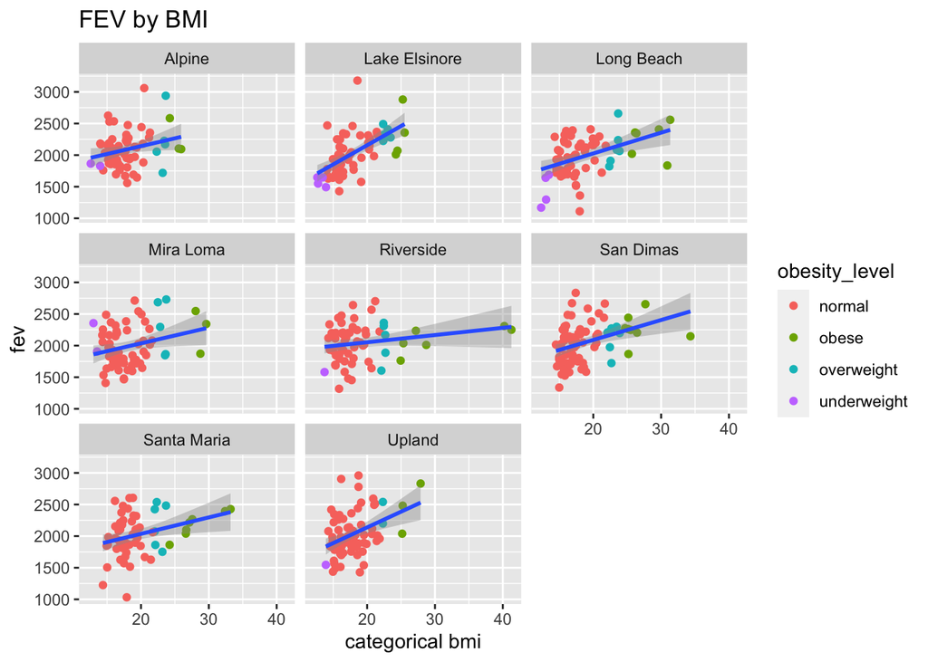

```r
chs$bmi_cat <- as.factor(ifelse(chs$bmi<14, '0',
                                        ifelse(chs$bmi<22, '1',
                                             ifelse(chs$bmi<24, '2',
                                                    ifelse(chs$bmi<44, '3')))))

ggplot(data = chs, aes(x= bmi, y = fev)) +
  geom_point(data = chs, aes(x= bmi, y = fev, color = obesity_level)) +
  geom_smooth(method = "lm") +
  labs(y = "fev", x = "categorical bmi", title = "FEV by BMI") +
  facet_wrap(~townname)
```

## 2.

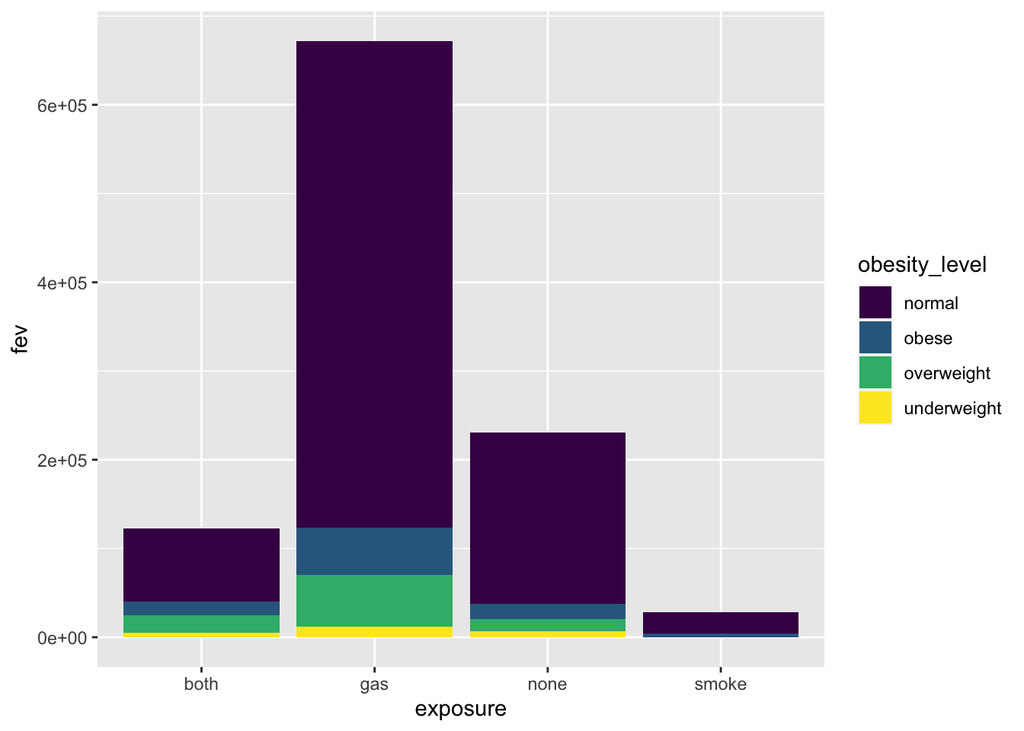

```r
ggplot(chs, aes(fill=obesity_level, y=fev, x=exposure)) +
  scale_fill_viridis_d() +
    geom_bar(position="stack", stat="identity")
```

## 3.

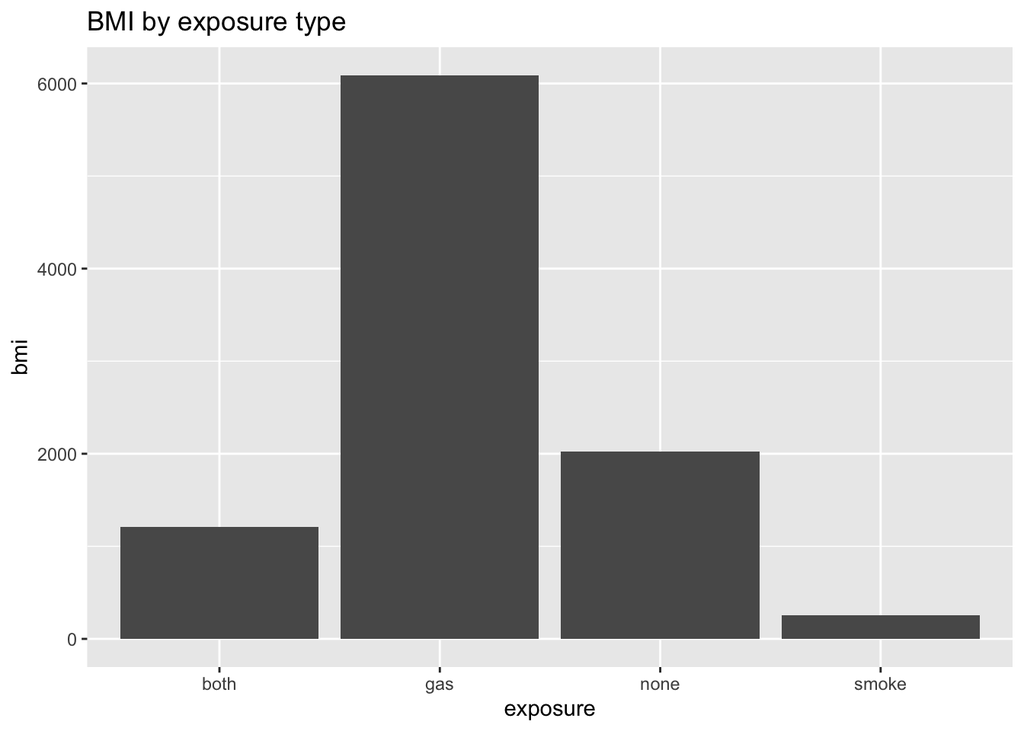

```r
chs %>%
  ggplot(aes(x = exposure, y = bmi)) +
  geom_bar(stat = "identity") +
  labs(title = "BMI by exposure type")
```

## 4.

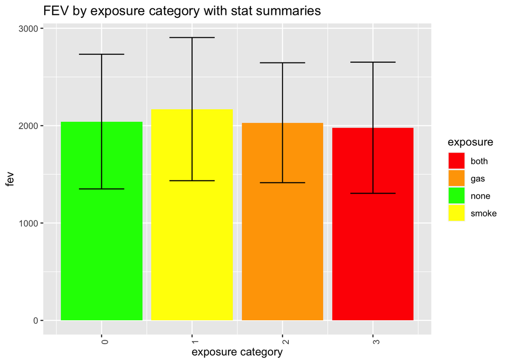

```r
chs %>%
  ggplot(aes(x = exposurecat, y = fev, fill = exposure)) +
  scale_fill_manual(
    values = c("red","orange","green","yellow")
  ) +
  stat_summary(fun.data = "mean_sdl", geom = "bar", position = "dodge") +
  stat_summary(fun.data = "mean_sdl", geom = "errorbar", position = "dodge", width = 0.5) +
  theme(axis.text.x = element_text(angle = 90)) +
  labs(x = "exposure category", title = "FEV by exposure category with stat summaries")
```

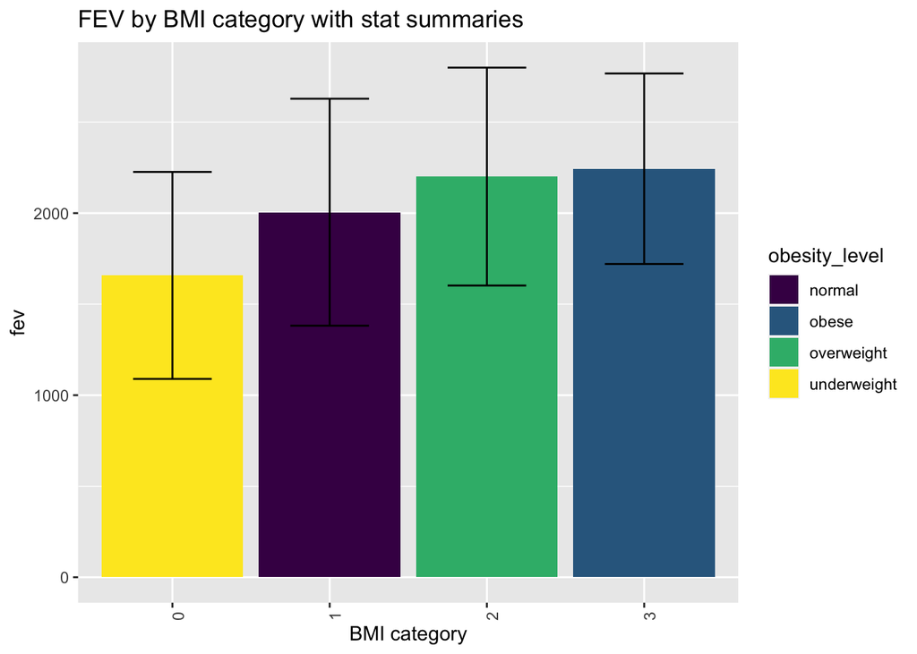

```r
chs %>%
  ggplot(aes(x = bmi_cat, y = fev, fill = obesity_level)) +
  scale_fill_viridis_d() +
  stat_summary(fun.data = "mean_sdl", geom = "bar", position = "dodge") +
  stat_summary(fun.data = "mean_sdl", geom = "errorbar", position = "dodge", width = 0.5) +
  theme(axis.text.x = element_text(angle = 90)) +
  labs(x = "BMI category", title = "FEV by BMI category with stat summaries")
```

## 5. Taken from previous EDA section^

```r
library(leaflet)

PM.pal<- colorNumeric(c('darkblue','orange','red'), domain=chs$pm25_mass)

leaflet(chs) %>%
  addProviderTiles('CartoDB.Positron') %>%
  addCircles(lat = ~lat, lng = ~lon,
             label = ~paste0(round(pm25_mass, 2)), color = ~ PM.pal(pm25_mass),
             opacity = 1, fillOpacity = 1, radius = 500
             ) %>%
  addLegend('bottomleft', pal=PM.pal, values=chs$pm25_mass,
            title= "PM_25 Mass emissions", opacity = 1)
```

[interactive chart not shown]

## 6.

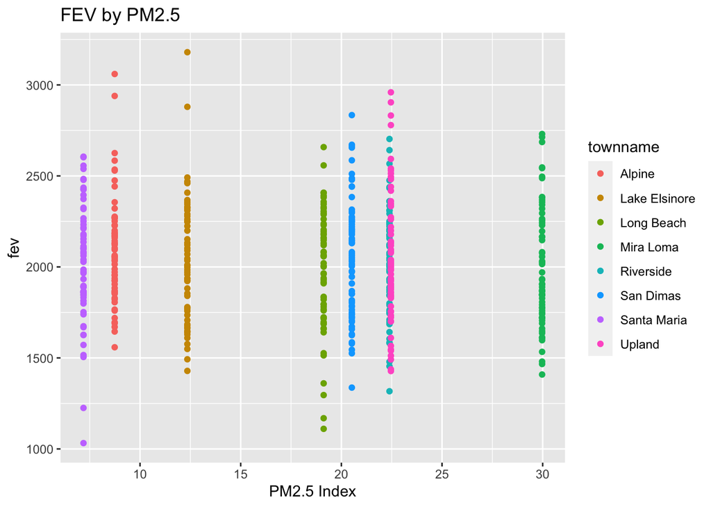

```r
chs %>%
  ggplot(aes(x= pm25_mass, y = fev, color = townname)) +
           geom_point() +
           labs(y = "fev", x = "PM2.5 Index", title = "FEV by PM2.5")
```

It does not appear that FEV is associated with PM2.5, likely other variables present in our data act as confounders, and we would need to create a model that accounts for all these other variables.